# Confidence Intervals for Variances from lm

Kevin

Friday, April 03, 2015

[figure not shown]

## Very Quick Example

Simulated 95% confidence interval for the residual standard error from an `lm` model for the mtcars dataset.

```r
m1 <- lm(mpg ~ wt, data = mtcars)
library(arm)
sims <- sim(m1, 1000)
quantile(sims@sigma, probs = c(.025, .975))
```

```
#>  2.5% 97.5%
#>  2.45  4.09
```

## Comparing CIs for Multilevel Models Using `lm`, `lmer`, and `Stan`

This is a very quick comparison of the confidence intervals for variance components. I put it up at the top so you we can see the results without having to follow along with all of my code. I used `lm`, `lmer`, and `Stan` to estimate the variability at each level in the sampling hierarchy and here are 95% confidence intervals using each method.

[output not shown]

The `Stan` and `lmer` results seem to be fairly similar and reasonably accurate. It does appear as though `Stan` is a little bit more conservative though. The `lm` results are worrisome though as the confidence intervals for tree and plot level variability are off by quite a bit.

## The Linear Model

The following linear model can be fit in R with the `lm` function.

$mpg_i = \beta_{0} + \beta_{1} wt_{i} + \epsilon_{i}$

$\epsilon_i \sim N(0, \sigma^2)$

```r
m2 <- lm(mpg ~ wt, data = mtcars)
summary(m2)
```

```
#>
#> Call:
#> lm(formula = mpg ~ wt, data = mtcars)
#>
#> Residuals:
#>    Min     1Q Median     3Q    Max
#> -4.543 -2.365 -0.125  1.410  6.873
#>
#> Coefficients:
#>             Estimate Std. Error t value Pr(>|t|)
#> (Intercept)   37.285      1.878   19.86  < 2e-16
#> wt            -5.344      0.559   -9.56  1.3e-10
#>
#> Residual standard error: 3.05 on 30 degrees of freedom
#> Multiple R-squared:  0.753,  Adjusted R-squared:  0.745
#> F-statistic: 91.4 on 1 and 30 DF,  p-value: 1.29e-10
```

In this model, there are three parameters: $\beta_0$, $\beta_1$, and $\sigma$. R estimates these parameters as 37.3, -5.3, and 3.0 respectively.

## The `sim` function

The `arm` package was written by Andrew Gelman and Yu-Song Su to complement Gelman’s *Data Analysis Using Regression and Multilevel/Hierarchical Models* book. In Chapter 7 of this book, they discuss how to use simulation for inferences in regression context.

To aid with these inferences, they provided the `sim` function in the package. This function simulates estimated parameters from the fitted model. In the code below, I simulate $\beta_0$, $\beta_1$, and $\sigma$ 1000 times. The `str` command reveals the structure of an R object. We can see that the simulated values are stored in two separate parts of the `sims` object. The estimated regression coefficients ($\beta_0$ and $\beta_1$) are stored in a matrix named `coef`, and the estimated variabilities (just $\sigma$ in this example) are named `sigma`.

```r
library(arm)
sims <- sim(m2, 1000)
str(sims)
```

```
#> Formal class 'sim' [package "arm"] with 2 slots
#>   ..@ coef : num [1:1000, 1:2] 37.8 40.1 36.6 38 36.1 ...
#>   .. ..- attr(*, "dimnames")=List of 2
#>   .. .. ..$ : NULL
#>   .. .. ..$ : chr [1:2] "(Intercept)" "wt"
#>   ..@ sigma: num [1:1000] 2.83 3.76 2.42 2.55 2.86 ...
```

## Confidence Intervals for $\sigma$

These simulations can be used to provide a summary of the model’s suggested values of the parameters.

```r
summary(sims@sigma) ## the @ sign is used because sim uses S4 class objects
```

```
#>    Min. 1st Qu.  Median    Mean 3rd Qu.    Max.
#>    2.23    2.84    3.08    3.13    3.36    5.04
```

We can visualize the distribution of simulated values.

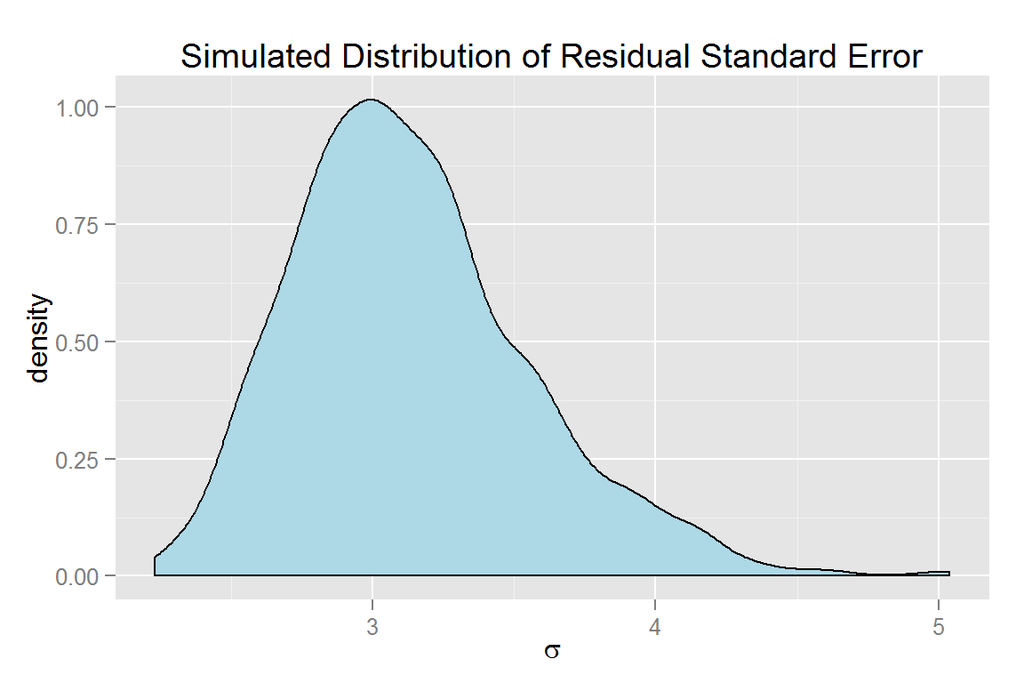

```r
library(ggplot2)
qplot(sims@sigma, geom = "density", fill = I("lightblue")) +
  labs(x = expression(sigma),
       title = "Simulated Distribution of Residual Standard Error")
```

To generate a confidence interval for $\sigma$, we can just extract the middle 95% of this distribution using the `quantile` function.

```r
quantile(sims@sigma, probs = c(.025, .975))
```

```
#>  2.5% 97.5%
#>  2.46  4.10
```

## CIs for Multilevel Models Using `lm`

Estimated 95% confidence intervals

```r
# models by level
mod_core <- lm(m_c ~ tree, data = by_core)
mod_tree <- lm(m_c ~ plot, data = by_tree)
mod_plot <- lm(m_c ~ site, data = by_plot)
mod_site <- lm(m_c ~ location, data = by_site)
# simulating RSE at each level
sim_sigmas <- sapply(list(mod_core, mod_tree, mod_plot, mod_site), function(x) {
  sim(x, 500)@sigma
})
# calculating CIs
apply(sim_sigmas, 2, quantile, probs = c(.025, .975)) %>%
  data.frame() %>%
  setNames(c("CoreLevel", "TreeLevel", "PlotLevel", "SiteLevel"))
```

```
#>       CoreLevel TreeLevel PlotLevel SiteLevel
#> 2.5%      0.627     0.487      1.06     0.518
#> 97.5%     0.921     0.839      3.63     2.361
```

Comparing using `ggvis`

```r
# turn simulations into long format
library(tidyr)  ## to go to long format
sim_sigmas_df <- sim_sigmas %>%
  data.frame() %>%   ## have to for tidyr
  setNames(c("core_sd", "tree_sd", "plot_sd", "site_sd")) %>%
  gather(level, sigma)  ## going to long format
# density plots
library(ggvis)
sim_sigmas_df %>%
  ggvis(~sigma, fill = ~level) %>%
  group_by(level) %>%
  layer_densities()
```

[output not shown]

Comparing to an `lmer` model

```r
library(lme4)
m3 <- lmer(m_c ~ location + (1 | site/plot/tree), data = by_core)
confint(m3)
```

```
#>             2.5 % 97.5 %
#> .sig01      0.000  0.404
#> .sig02      0.891  2.125
#> .sig03      0.000  1.258
#> .sigma      0.628  0.874
#> (Intercept) 1.016  3.859
#> locationLEF 0.132  3.648
```

## Bayesian Hierarchical Model with Stan

Here’s the model written and fit in Stan. I’m omitting all the Stan messages to save space.

```r
stan_mod <- "
data {
  int N;
  int J;
  int K;
  int L;

  vector[N] y;
  int<lower=0, upper=1> locLEF[N];
  int<lower=1, upper=J> site[N];
  int<lower=1, upper=K> plot[N];
  int<lower=1, upper=L> tree[N];
}
parameters {
  real beta0;
  real beta1;
  real<lower=0, upper=10> sig_site;
  real<lower=0, upper=10> sig_plot;
  real<lower=0, upper=10> sig_tree;
  real<lower=0, upper=10> sig_core;

  vector[J] b_site;
  vector[K] b_plot;
  vector[L] b_tree;
}
transformed parameters {
  vector[N] yhat;

  for(i in 1:N)
    yhat[i] <- beta0 + beta1 * locLEF[i] +
    b_site[site[i]] +  b_plot[plot[i]] + b_tree[tree[i]];
}
model {
  y ~ normal(yhat, sig_core);
  beta0 ~ normal(0, 100);
  beta1 ~ normal(0, 100);
  b_site ~ normal(0, sig_site);
  b_plot ~ normal(0, sig_plot);
  b_tree ~ normal(0, sig_tree);
}
"
library(rstan)
trans <- stanc(model_code = stan_mod)
comp <- stan_model(stanc_ret = trans)

# data for stan
dat_stan <- with(by_core %>% droplevels(),
                 list(N = nrow(by_core),
                      J = n_distinct(site),
                      K = n_distinct(plot),
                      L = n_distinct(tree),
                      y = m_c,
                      locLEF = ifelse(location == "LEF", 1, 0),
                      site = as.integer(as.factor(site)),
                      plot = as.integer(as.factor(plot)),
                      tree = as.integer(as.factor(tree))
                      )
                 )
inits <- list(beta0 = 1,
       beta1 = 1,
       b_site = rep(1, 6),
       b_plot = rep(1, 12),
       b_tree = rep(1, 40),
       sig_site = sigma_site,
       sig_plot = sigma_plot,
       sig_tree = sigma_tree,
       sig_core = sigma_core)
# sampling parameters
samps <- sampling(comp, data = dat_stan, chains = 4, iter = 2000, thin = 8,
                  init = list(inits, inits, inits, inits))
```

Stan is having a really tough time identifying $\sigma_{tree}$. I’m guessing this is because it is so small relative to the others.

```r
print(samps, pars = c("sig_site", "sig_plot", "sig_tree", "sig_core"))
```

```
#> Inference for Stan model: stan_mod.
#> 4 chains, each with iter=2000; warmup=1000; thin=8;
#> post-warmup draws per chain=125, total post-warmup draws=500.
#>
#>          mean se_mean   sd 2.5%  25%  50%  75% 97.5% n_eff Rhat
#> sig_site 1.25    0.09 1.28 0.08 0.41 0.90 1.52  4.98   189 1.00
#> sig_plot 1.74    0.03 0.58 1.01 1.35 1.61 1.99  3.02   385 1.00
#> sig_tree 0.13    0.01 0.10 0.01 0.05 0.10 0.20  0.38    56 1.03
#> sig_core 0.74    0.00 0.06 0.63 0.70 0.74 0.78  0.88   500 1.00
#>
#> Samples were drawn using NUTS(diag_e) at Wed Apr 08 09:15:07 2015.
#> For each parameter, n_eff is a crude measure of effective sample size,
#> and Rhat is the potential scale reduction factor on split chains (at
#> convergence, Rhat=1).
```

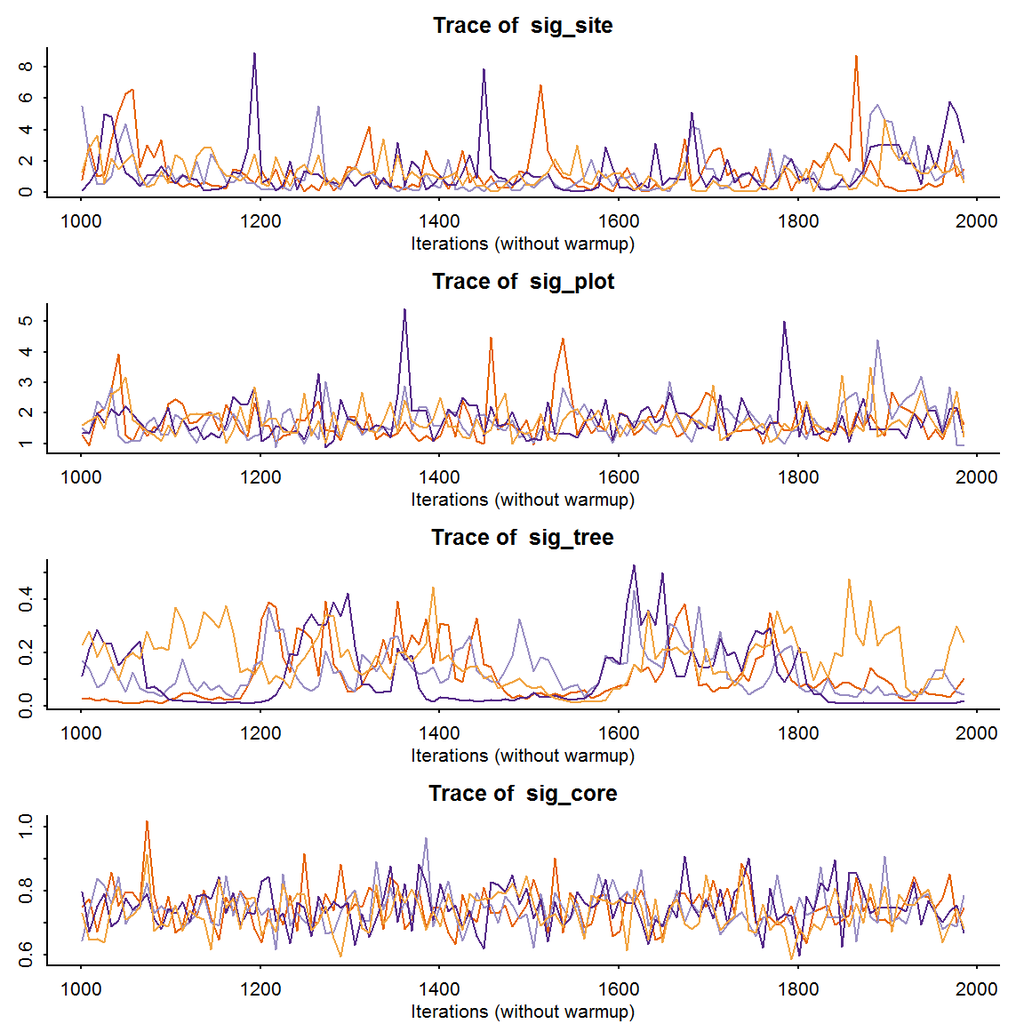

```r
traceplot(samps, pars = c("sig_site", "sig_plot", "sig_tree", "sig_core"), inc_warmup = F)
```

Stan gives us generally the same results as `lmer`. The major difference is is that Stan has a much wider intervals for the variability between sites. I have no idea why this is.

## Code to Simulate Data

```r
library(dplyr)
set.seed(42)

# variability at each level
sigma_site <- runif(1, 0, 1)
sigma_plot <- runif(1, 0, 1)
sigma_tree <- runif(1, 0, 1)
sigma_core <- runif(1, 0, 1)

# LEF   ------------------------------------------------

# number of observations at each level
n_sites <- 4
n_plots <- 2
n_trees <- 6
n_cores <- 1
n_obs <- prod(n_sites, n_plots, n_trees, n_cores)

# simulating data
lef <- data_frame(
  location = "LEF",
  site = paste0("S", rep(1:n_sites, each = n_obs / n_sites)),
  plot = paste0("P", rep(rep(1:n_plots, each = n_obs / (n_sites * n_plots)),
                         times = n_sites)),
  tree = paste0("T", rep(rep(1:n_trees, each = n_obs / (n_sites * n_plots * n_trees)),
                         times = n_sites * n_plots)),
  core = paste0("C", rep(rep(1:n_cores, each = n_obs / (n_sites * n_plots * n_trees * n_cores)))),
  species = ifelse(substr(tree, 2, 2) <= 3, "DF",
                   ifelse(site == "S1", "WL",
                          ifelse(site == "S2", "PP",
                                 ifelse(site == "S3", "EB",
                                        "DR")))),
  elevation = ifelse(site %in% c("S1", "S2"), "H", "L"),
  aspect = ifelse(site %in% c("S1", "S3"), "N", "S"),
  topo = ifelse(plot == "P1", "valley", "slope")
) %>%
  mutate(int = rnorm(1, 3, .5)) %>%
  group_by(site) %>%
  mutate(b_site = rnorm(1, 0, sigma_site)) %>%
  group_by(site, plot) %>%
  mutate(b_plot = rnorm(1, 0, sigma_plot)) %>%
  group_by(site, plot, tree) %>%
  mutate(b_tree = rnorm(1, 0, sigma_tree)) %>%
  group_by(site, plot, tree, core) %>%
  mutate(b_core = rnorm(1, 0, sigma_core)) %>%
  ungroup() %>%
  mutate(m_c = int + b_site + b_plot + b_tree + b_core)

# BZN ---------------------------------------------------

n_sites <- 2
n_plots <- 2
n_trees <- 4
n_cores <- 4
n_obs <- prod(n_sites, n_plots, n_trees, n_cores)

bzn <- data_frame(
  location = "BZN",
  site = paste0("S", rep(1:n_sites, each = n_obs / n_sites)),
  plot = paste0("P", rep(rep(1:n_plots, each = n_obs / (n_sites * n_plots)),
                         times = n_sites)),
  tree = paste0("T", rep(rep(1:n_trees, each = n_obs / (n_sites * n_plots * n_trees)),
                         times = n_sites * n_plots)),
  core = paste0("C", rep(rep(1:n_cores, each = n_obs / (n_sites * n_plots * n_trees * n_cores)),
                         times = n_sites * n_plots * n_trees)),
  species = "DF",
  elevation = ifelse(site %in% c("S1", "S2"), "H", "L"),
  aspect = ifelse(site %in% c("S1", "S3"), "N", "S"),
  canopy = ifelse(plot == "P1", "open", "closed")
)  %>%
  mutate(int = rnorm(1, 3, .5)) %>%
  group_by(site) %>%
  mutate(b_site = rnorm(1, 0, sigma_site)) %>%
  group_by(site, plot) %>%
  mutate(b_plot = rnorm(1, 0, sigma_plot)) %>%
  group_by(site, plot, tree) %>%
  mutate(b_tree = rnorm(1, 0, sigma_tree)) %>%
  group_by(site, plot, tree, core) %>%
  mutate(b_core = rnorm(1, 0, sigma_core)) %>%
  ungroup() %>%
  mutate(m_c = int + b_site + b_plot + b_tree + b_core)

# for each level ------------------------------------------
tree_data <- bind_rows(bzn, lef) %>%
  filter(species == "DF")            ## only Douglas Firs

# core level
by_core <- tree_data %>%
  group_by(location, site, plot, tree, core) %>%
  summarise(m_c = mean(m_c)) %>%
  ungroup() %>%
  mutate(site = interaction(location, site),
         plot = interaction(location, site, plot),
         tree = interaction(location, site, plot, tree),
         core = interaction(location, site, plot, tree))
# tree level
by_tree <- tree_data %>%
  group_by(location, site, plot, tree) %>%
  summarise(m_c = mean(m_c)) %>%
  ungroup() %>%
  mutate(site = interaction(location, site),
         plot = interaction(location, site, plot),
         tree = interaction(location, site, plot, tree))
# plot level
by_plot <- tree_data %>%
  group_by(location, site, plot) %>%
  summarise(m_c = mean(m_c)) %>%
  ungroup() %>%
  mutate(site = interaction(location, site),
         plot = interaction(location, site, plot))
# site level
by_site <- tree_data %>%
  group_by(location, site) %>%
  summarise(m_c = mean(m_c)) %>%
  ungroup() %>%
  mutate(site = interaction(location, site))
```